# Practice Model Selection

Alexandra Boville

2024-04-15

Libraries Used in this Exercise

```r
library(tidyverse)
```

```r
library(naniar)
library(AICcmodavg)
library(ggplot2)
library(jtools)
library(MuMIn)
```

Loading Dataset

```r
f <- "https://raw.githubusercontent.com/difiore/ada-2024-datasets/main/Mammal_lifehistories_v2.txt"

d <- read_tsv(f, col_names = TRUE)
d
```

```
## # A tibble: 1,440 × 14
##    order        family      Genus species `mass(g)` `gestation(mo)` `newborn(g)`
##    <chr>        <chr>       <chr> <chr>       <dbl>           <dbl>        <dbl>
##  1 Artiodactyla Antilocapr… Anti… americ…    45375             8.13        3246.
##  2 Artiodactyla Bovidae     Addax nasoma…   182375             9.39        5480
##  3 Artiodactyla Bovidae     Aepy… melamp…    41480             6.35        5093
##  4 Artiodactyla Bovidae     Alce… busela…   150000             7.9        10167.
##  5 Artiodactyla Bovidae     Ammo… clarkei    28500             6.8         -999
##  6 Artiodactyla Bovidae     Ammo… lervia     55500             5.08        3810
##  7 Artiodactyla Bovidae     Anti… marsup…    30000             5.72        3910
##  8 Artiodactyla Bovidae     Anti… cervic…    37500             5.5         3846
##  9 Artiodactyla Bovidae     Bison bison     497667.            8.93       20000
## 10 Artiodactyla Bovidae     Bison bonasus   500000             9.14       23000.
## # ℹ 1,430 more rows
## # ℹ 7 more variables: `weaning(mo)` <dbl>, `wean mass(g)` <dbl>,
## #   `AFR(mo)` <dbl>, `max. life(mo)` <dbl>, `litter size` <dbl>,
## #   `litters/year` <dbl>, refs <dbl>
```

# Step 1: Replacing -999 values with NA

```r
d %>% replace_with_na_all(condition = ~.x == -999)
```

```
## # A tibble: 1,440 × 14
##    order        family      Genus species `mass(g)` `gestation(mo)` `newborn(g)`
##    <chr>        <chr>       <chr> <chr>       <dbl>           <dbl>        <dbl>
##  1 Artiodactyla Antilocapr… Anti… americ…    45375             8.13        3246.
##  2 Artiodactyla Bovidae     Addax nasoma…   182375             9.39        5480
##  3 Artiodactyla Bovidae     Aepy… melamp…    41480             6.35        5093
##  4 Artiodactyla Bovidae     Alce… busela…   150000             7.9        10167.
##  5 Artiodactyla Bovidae     Ammo… clarkei    28500             6.8           NA
##  6 Artiodactyla Bovidae     Ammo… lervia     55500             5.08        3810
##  7 Artiodactyla Bovidae     Anti… marsup…    30000             5.72        3910
##  8 Artiodactyla Bovidae     Anti… cervic…    37500             5.5         3846
##  9 Artiodactyla Bovidae     Bison bison     497667.            8.93       20000
## 10 Artiodactyla Bovidae     Bison bonasus   500000             9.14       23000.
## # ℹ 1,430 more rows
## # ℹ 7 more variables: `weaning(mo)` <dbl>, `wean mass(g)` <dbl>,
## #   `AFR(mo)` <dbl>, `max. life(mo)` <dbl>, `litter size` <dbl>,
## #   `litters/year` <dbl>, refs <dbl>
```

# Steps 2 + 3: Droping the variables litter size and refs and log transforming all remaining variables

```r
d <- d %>%
  subset(select = -c(refs, `litter size`)) %>%
  mutate(
    logMass = log(`mass(g)`),
    logGestation = log(`gestation(mo)`),
    logNewborn = log(`newborn(g)`),
    logWeaning = log(`weaning(mo)`),
    logWean.Mass = log(`wean mass(g)`),
    logAFR = log(`AFR(mo)`),
    logMax.Life = log(`max. life(mo)`),
    `logLitters/Year` = log(`litters/year`)
  )
d
```

```
## # A tibble: 1,440 × 20
##    order        family      Genus species `mass(g)` `gestation(mo)` `newborn(g)`
##    <chr>        <chr>       <chr> <chr>       <dbl>           <dbl>        <dbl>
##  1 Artiodactyla Antilocapr… Anti… americ…    45375             8.13        3246.
##  2 Artiodactyla Bovidae     Addax nasoma…   182375             9.39        5480
##  3 Artiodactyla Bovidae     Aepy… melamp…    41480             6.35        5093
##  4 Artiodactyla Bovidae     Alce… busela…   150000             7.9        10167.
##  5 Artiodactyla Bovidae     Ammo… clarkei    28500             6.8         -999
##  6 Artiodactyla Bovidae     Ammo… lervia     55500             5.08        3810
##  7 Artiodactyla Bovidae     Anti… marsup…    30000             5.72        3910
##  8 Artiodactyla Bovidae     Anti… cervic…    37500             5.5         3846
##  9 Artiodactyla Bovidae     Bison bison     497667.            8.93       20000
## 10 Artiodactyla Bovidae     Bison bonasus   500000             9.14       23000.
## # ℹ 1,430 more rows
## # ℹ 13 more variables: `weaning(mo)` <dbl>, `wean mass(g)` <dbl>,
## #   `AFR(mo)` <dbl>, `max. life(mo)` <dbl>, `litters/year` <dbl>,
## #   logMass <dbl>, logGestation <dbl>, logNewborn <dbl>, logWeaning <dbl>,
## #   logWean.Mass <dbl>, logAFR <dbl>, logMax.Life <dbl>,
## #   `logLitters/Year` <dbl>
```

# Step 4: Regressing Variables

```r
relGest <- resid(lm(logGestation ~ logMass, data = d, na.action = na.exclude))
relWean <- resid(lm(logWeaning ~ logMass, data = d, na.action = na.exclude))
relAFR <- resid(lm(logAFR ~ logMass, data = d, na.action = na.exclude))
relLife <- resid(lm(logMax.Life ~ logMass, data = d, na.action = na.exclude))
relNewbornMass <- resid(lm(logNewborn ~ logMass, data = d, na.action = na.exclude))
relWeaningMass <- resid(lm(logWean.Mass ~ logMass, data = d, na.action = na.exclude))

d$relGestation <- relGest
d$relWeaning <- relWean
d$relAFR <- relAFR
d$relLife <- relLife
d$relNewbornMass <- relNewbornMass
d$relWeaningMass <- relWeaningMass

d
```

```
## # A tibble: 1,440 × 26
##    order        family      Genus species `mass(g)` `gestation(mo)` `newborn(g)`
##    <chr>        <chr>       <chr> <chr>       <dbl>           <dbl>        <dbl>
##  1 Artiodactyla Antilocapr… Anti… americ…    45375             8.13        3246.
##  2 Artiodactyla Bovidae     Addax nasoma…   182375             9.39        5480
##  3 Artiodactyla Bovidae     Aepy… melamp…    41480             6.35        5093
##  4 Artiodactyla Bovidae     Alce… busela…   150000             7.9        10167.
##  5 Artiodactyla Bovidae     Ammo… clarkei    28500             6.8         -999
##  6 Artiodactyla Bovidae     Ammo… lervia     55500             5.08        3810
##  7 Artiodactyla Bovidae     Anti… marsup…    30000             5.72        3910
##  8 Artiodactyla Bovidae     Anti… cervic…    37500             5.5         3846
##  9 Artiodactyla Bovidae     Bison bison     497667.            8.93       20000
## 10 Artiodactyla Bovidae     Bison bonasus   500000             9.14       23000.
## # ℹ 1,430 more rows
## # ℹ 19 more variables: `weaning(mo)` <dbl>, `wean mass(g)` <dbl>,
## #   `AFR(mo)` <dbl>, `max. life(mo)` <dbl>, `litters/year` <dbl>,
## #   logMass <dbl>, logGestation <dbl>, logNewborn <dbl>, logWeaning <dbl>,
## #   logWean.Mass <dbl>, logAFR <dbl>, logMax.Life <dbl>,
## #   `logLitters/Year` <dbl>, relGestation <dbl>, relWeaning <dbl>,
## #   relAFR <dbl>, relLife <dbl>, relNewbornMass <dbl>, relWeaningMass <dbl>
```

# Step 5: Plotting Residuals

## Plotting residuals of max lifespan (relLife) in relation to Order

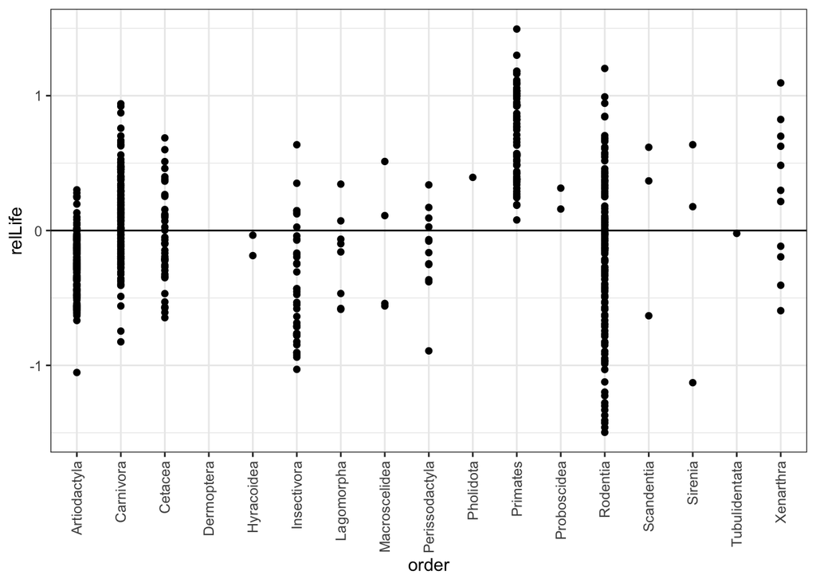

```r
ggplot(d, aes(x = order, y = relLife)) +
  geom_point() +
  geom_hline(yintercept = 0) +
  scale_x_discrete(guide = guide_axis(angle = 90)) +
  theme_bw()
```

Primates, Rodentia and Xenarthra have the highest residuals of relative max lifespan.

## Plotting residuals of newborn mass (relNewbornMass) in relation to Order

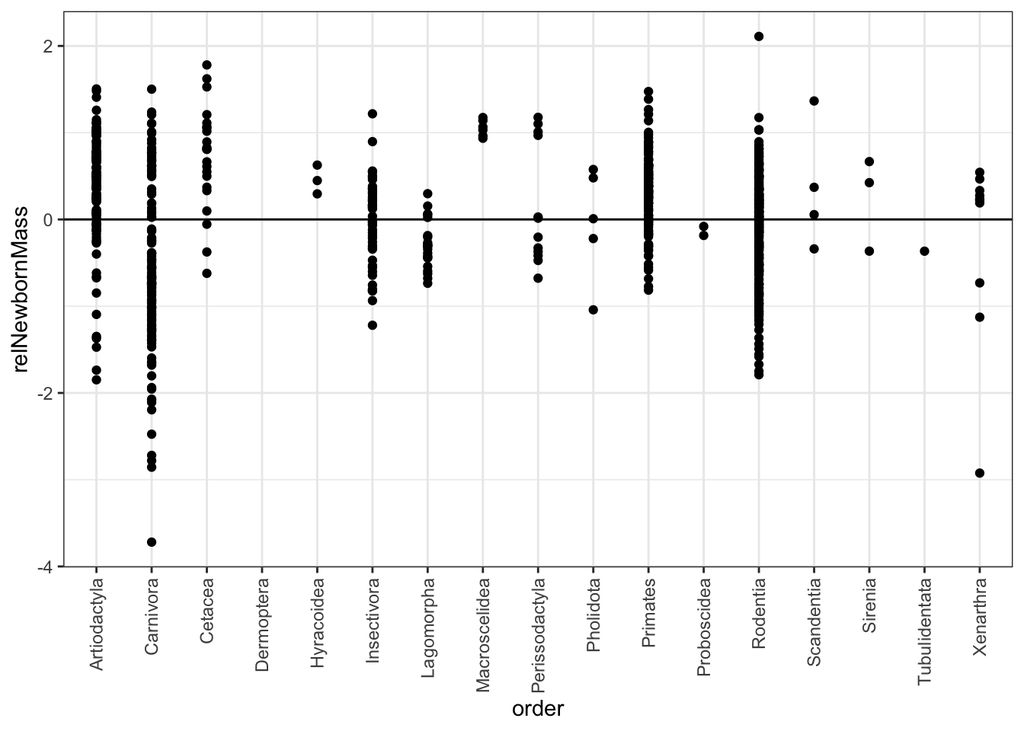

```r
ggplot(d, aes(x = order, y = relNewbornMass)) +
  geom_point() +
  geom_hline(yintercept = 0) +
  scale_x_discrete(guide = guide_axis(angle = 90)) +
  theme_bw()
```

Cetacea and Rodentia have the highest residuals of relative newborn mass.

## Plotting residuals of weaning mass (relWeaningMass) in relation to Order

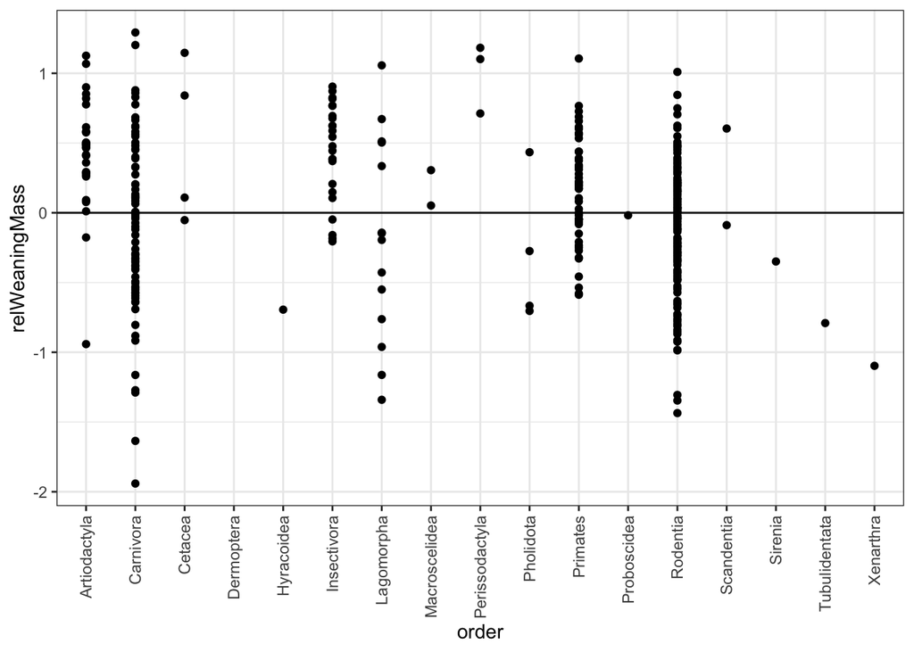

```r
ggplot(d, aes(x = order, y = relWeaningMass)) +
  geom_point() +
  geom_hline(yintercept = 0) +
  scale_x_discrete(guide = guide_axis(angle = 90)) +
  theme_bw()
```

Carnivora, Primates, Artiodactyla and Perissodactyla have the highest residuals for relative weaning mass.

# Step 6: Running Models and Model Selection

Droping NA values from dataset

```r
d <- d %>%
  drop_na()

d
```

```
## # A tibble: 206 × 26
##    order        family      Genus species `mass(g)` `gestation(mo)` `newborn(g)`
##    <chr>        <chr>       <chr> <chr>       <dbl>           <dbl>        <dbl>
##  1 Artiodactyla Antilocapr… Anti… americ…    45375             8.13        3246.
##  2 Artiodactyla Bovidae     Aepy… melamp…    41480             6.35        5093
##  3 Artiodactyla Bovidae     Bison bison     497667.            8.93       20000
##  4 Artiodactyla Bovidae     Gaze… subgut…    25500             5.37        2427.
##  5 Artiodactyla Bovidae     Kobus kob        58600             8.38        4938.
##  6 Artiodactyla Bovidae     Mado… kirkii      4877.            5.77         654
##  7 Artiodactyla Bovidae     Ovis  canade…    68167.            5.99        4267.
##  8 Artiodactyla Bovidae     Saiga tatari…    38250             4.94        3365.
##  9 Artiodactyla Bovidae     Sync… caffer    504667.           11.0        42862.
## 10 Artiodactyla Camelidae   Came… dromed…   434000            12.6        35808.
## # ℹ 196 more rows
## # ℹ 19 more variables: `weaning(mo)` <dbl>, `wean mass(g)` <dbl>,
## #   `AFR(mo)` <dbl>, `max. life(mo)` <dbl>, `litters/year` <dbl>,
## #   logMass <dbl>, logGestation <dbl>, logNewborn <dbl>, logWeaning <dbl>,
## #   logWean.Mass <dbl>, logAFR <dbl>, logMax.Life <dbl>,
## #   `logLitters/Year` <dbl>, relGestation <dbl>, relWeaning <dbl>,
## #   relAFR <dbl>, relLife <dbl>, relNewbornMass <dbl>, relWeaningMass <dbl>
```

## Using Forward Selection to Determine which variables best predict max.life from predictor variables gestation(mo), newborn(g), weaning(mo), wean mass(g), litters/year, and overall body mass(g).

```r
m0 <- lm(data = d, logMax.Life ~ 1) #intercept only model
summary(m0)
```

```
##
## Call:
## lm(formula = logMax.Life ~ 1, data = d)
##
## Residuals:
##     Min      1Q  Median      3Q     Max
## -2.5729 -0.7174  0.2301  0.6584  2.1276
##
## Coefficients:
##             Estimate Std. Error t value Pr(>|t|)
## (Intercept)  5.05776    0.06344   79.73   <2e-16 ***
## ---
## Signif. codes:  0 '***' 0.001 '**' 0.01 '*' 0.05 '.' 0.1 ' ' 1
##
## Residual standard error: 0.9105 on 205 degrees of freedom
```

```r
add1(m0, scope = . ~ . + logGestation + logNewborn + logWeaning + logWean.Mass + `logLitters/Year` + logMass, test = "F")
```

```
## Single term additions
##
## Model:
## logMax.Life ~ 1
##                   Df Sum of Sq     RSS      AIC F value    Pr(>F)
## <none>                         169.953  -37.625
## logGestation       1   116.369  53.584 -273.405  443.03 < 2.2e-16 ***
## logNewborn         1   107.385  62.568 -241.474  350.12 < 2.2e-16 ***
## logWeaning         1    94.463  75.490 -202.798  255.27 < 2.2e-16 ***
## logWean.Mass       1   111.575  58.378 -255.753  389.90 < 2.2e-16 ***
## `logLitters/Year`  1    95.681  74.272 -206.149  262.80 < 2.2e-16 ***
## logMass            1   109.739  60.214 -249.373  371.78 < 2.2e-16 ***
## ---
## Signif. codes:  0 '***' 0.001 '**' 0.01 '*' 0.05 '.' 0.1 ' ' 1
```

```r
m1 <- update(m0, formula = . ~ . + logGestation) #logGestation has the highest F value and the lowest RSS and the lowest AIC value so has the most explanatory power even though all predictor variables are significant
summary(m1)
```

```
##
## Call:
## lm(formula = logMax.Life ~ logGestation, data = d)
##
## Residuals:
##      Min       1Q   Median       3Q      Max
## -1.51142 -0.33360 -0.02311  0.36463  1.20767
##
## Coefficients:
##              Estimate Std. Error t value Pr(>|t|)
## (Intercept)   4.26554    0.05188   82.22   <2e-16 ***
## logGestation  0.78604    0.03734   21.05   <2e-16 ***
## ---
## Signif. codes:  0 '***' 0.001 '**' 0.01 '*' 0.05 '.' 0.1 ' ' 1
##
## Residual standard error: 0.5125 on 204 degrees of freedom
## Multiple R-squared:  0.6847, Adjusted R-squared:  0.6832
## F-statistic:   443 on 1 and 204 DF,  p-value: < 2.2e-16
```

```r
add1(m1, scope = . ~ . + logGestation + logNewborn + logWeaning + logWean.Mass + `logLitters/Year` + logMass, test = "F")
```

```
## Single term additions
##
## Model:
## logMax.Life ~ logGestation
##                   Df Sum of Sq    RSS     AIC F value    Pr(>F)
## <none>                         53.584 -273.40
## logNewborn         1    2.0769 51.507 -279.55  8.1854  0.004665 **
## logWeaning         1    5.5698 48.014 -294.01 23.5488 2.424e-06 ***
## logWean.Mass       1    5.3164 48.268 -292.93 22.3595 4.225e-06 ***
## `logLitters/Year`  1    9.6629 43.921 -312.37 44.6611 2.212e-10 ***
## logMass            1    6.1738 47.410 -296.62 26.4347 6.396e-07 ***
## ---
## Signif. codes:  0 '***' 0.001 '**' 0.01 '*' 0.05 '.' 0.1 ' ' 1
```

```r
m2 <- update(m1, formula = . ~ . + `logLitters/Year`) #`logLitters/Year` has the highest F value and the lowest RSS and the lowest AIC value so has the most explanatory power
summary(m2)
```

```
##
## Call:
## lm(formula = logMax.Life ~ logGestation + `logLitters/Year`,
##     data = d)
##
## Residuals:
##      Min       1Q   Median       3Q      Max
## -1.59914 -0.24920 -0.04264  0.28943  1.12845
##
## Coefficients:
##                   Estimate Std. Error t value Pr(>|t|)
## (Intercept)        4.57846    0.06641  68.947  < 2e-16 ***
## logGestation       0.56317    0.04755  11.844  < 2e-16 ***
## `logLitters/Year` -0.43503    0.06510  -6.683 2.21e-10 ***
## ---
## Signif. codes:  0 '***' 0.001 '**' 0.01 '*' 0.05 '.' 0.1 ' ' 1
##
## Residual standard error: 0.4651 on 203 degrees of freedom
## Multiple R-squared:  0.7416, Adjusted R-squared:  0.739
## F-statistic: 291.3 on 2 and 203 DF,  p-value: < 2.2e-16
```

```r
add1(m2, scope = . ~ . + logGestation + logNewborn + logWeaning + logWean.Mass + `logLitters/Year` + logMass, test = "F")
```

```
## Single term additions
##
## Model:
## logMax.Life ~ logGestation + `logLitters/Year`
##              Df Sum of Sq    RSS     AIC F value    Pr(>F)
## <none>                    43.921 -312.37
## logNewborn    1   1.49260 42.428 -317.49  7.1062 0.0083033 **
## logWeaning    1   0.71682 43.204 -313.76  3.3515 0.0686190 .
## logWean.Mass  1   2.53348 41.388 -322.61 12.3651 0.0005401 ***
## logMass       1   2.96128 40.960 -324.75 14.6040 0.0001765 ***
## ---
## Signif. codes:  0 '***' 0.001 '**' 0.01 '*' 0.05 '.' 0.1 ' ' 1
```

```r
m3 <- update(m2, formula = . ~ . + logMass) #logMass has the highest F value and the lowest RSS and the lowest AIC value so has the most explanatory power
summary(m3)
```

```
##
## Call:
## lm(formula = logMax.Life ~ logGestation + `logLitters/Year` +
##     logMass, data = d)
##
## Residuals:
##      Min       1Q   Median       3Q      Max
## -1.53014 -0.23551 -0.02369  0.29969  1.10433
##
## Coefficients:
##                   Estimate Std. Error t value Pr(>|t|)
## (Intercept)        4.17095    0.12452  33.498  < 2e-16 ***
## logGestation       0.38764    0.06503   5.961 1.10e-08 ***
## `logLitters/Year` -0.36868    0.06537  -5.640 5.68e-08 ***
## logMass            0.07220    0.01889   3.822 0.000177 ***
## ---
## Signif. codes:  0 '***' 0.001 '**' 0.01 '*' 0.05 '.' 0.1 ' ' 1
##
## Residual standard error: 0.4503 on 202 degrees of freedom
## Multiple R-squared:  0.759,  Adjusted R-squared:  0.7554
## F-statistic: 212.1 on 3 and 202 DF,  p-value: < 2.2e-16
```

```r
add1(m3, scope = . ~ . + logGestation + logNewborn + logWeaning + logWean.Mass + `logLitters/Year` + logMass, test = "F")
```

```
## Single term additions
##
## Model:
## logMax.Life ~ logGestation + `logLitters/Year` + logMass
##              Df Sum of Sq    RSS     AIC F value  Pr(>F)
## <none>                    40.960 -324.75
## logNewborn    1   0.51379 40.446 -325.35  2.5533 0.11163
## logWeaning    1   1.45315 39.507 -330.19  7.3933 0.00712 **
## logWean.Mass  1   0.00486 40.955 -322.77  0.0238 0.87742
## ---
## Signif. codes:  0 '***' 0.001 '**' 0.01 '*' 0.05 '.' 0.1 ' ' 1
```

```r
m4 <- update(m3, formula = . ~ . + logWeaning) #logWeaning has the highest F value and the lowest RSS and the lowest AIC value so has the most explanatory power
summary(m4)
```

```
##
## Call:
## lm(formula = logMax.Life ~ logGestation + `logLitters/Year` +
##     logMass + logWeaning, data = d)
##
## Residuals:
##      Min       1Q   Median       3Q      Max
## -1.47943 -0.25454 -0.03637  0.30307  1.03470
##
## Coefficients:
##                   Estimate Std. Error t value Pr(>|t|)
## (Intercept)        4.03241    0.13276  30.374  < 2e-16 ***
## logGestation       0.29528    0.07248   4.074 6.65e-05 ***
## `logLitters/Year` -0.25252    0.07724  -3.269  0.00127 **
## logMass            0.08226    0.01897   4.337 2.28e-05 ***
## logWeaning         0.14159    0.05207   2.719  0.00712 **
## ---
## Signif. codes:  0 '***' 0.001 '**' 0.01 '*' 0.05 '.' 0.1 ' ' 1
##
## Residual standard error: 0.4433 on 201 degrees of freedom
## Multiple R-squared:  0.7675, Adjusted R-squared:  0.7629
## F-statistic: 165.9 on 4 and 201 DF,  p-value: < 2.2e-16
```

```r
add1(m4, scope = . ~ . + logGestation + logNewborn + logWeaning + logWean.Mass + `logLitters/Year` + logMass, test = "F")
```

```
## Single term additions
##
## Model:
## logMax.Life ~ logGestation + `logLitters/Year` + logMass + logWeaning
##              Df Sum of Sq    RSS     AIC F value Pr(>F)
## <none>                    39.507 -330.19
## logNewborn    1  0.213874 39.293 -329.31  1.0886 0.2980
## logWean.Mass  1  0.006196 39.500 -328.22  0.0314 0.8596
```

```r
m5 <- update(m4, formula = . ~ . + logNewborn) #logNewborn has the highest F value and the lowest RSS and the lowest AIC value so has the most explanatory power
summary(m5)
```

```
##
## Call:
## lm(formula = logMax.Life ~ logGestation + `logLitters/Year` +
##     logMass + logWeaning + logNewborn, data = d)
##
## Residuals:
##      Min       1Q   Median       3Q      Max
## -1.42246 -0.24528 -0.02812  0.29558  1.02301
##
## Coefficients:
##                   Estimate Std. Error t value Pr(>|t|)
## (Intercept)        3.92020    0.17083  22.948  < 2e-16 ***
## logGestation       0.36435    0.09815   3.712 0.000266 ***
## `logLitters/Year` -0.23652    0.07873  -3.004 0.003005 **
## logMass            0.12140    0.04203   2.888 0.004299 **
## logWeaning         0.12932    0.05337   2.423 0.016292 *
## logNewborn        -0.05423    0.05197  -1.043 0.298037
## ---
## Signif. codes:  0 '***' 0.001 '**' 0.01 '*' 0.05 '.' 0.1 ' ' 1
##
## Residual standard error: 0.4432 on 200 degrees of freedom
## Multiple R-squared:  0.7688, Adjusted R-squared:  0.763
## F-statistic:   133 on 5 and 200 DF,  p-value: < 2.2e-16
```

```r
add1(m5, scope = . ~ . + logGestation + logNewborn + logWeaning + logWean.Mass + `logLitters/Year` + logMass, test = "F")
```

```
## Single term additions
##
## Model:
## logMax.Life ~ logGestation + `logLitters/Year` + logMass + logWeaning +
##     logNewborn
##              Df Sum of Sq    RSS     AIC F value Pr(>F)
## <none>                    39.293 -329.31
## logWean.Mass  1  0.022859 39.270 -327.43  0.1158  0.734
```

```r
m6 <- update(m5, formula = . ~ . + logWean.Mass) #logWean.Mass has the highest F value and the lowest RSS and the lowest AIC value so has the most explanatory power
summary(m6)
```

```
##
## Call:
## lm(formula = logMax.Life ~ logGestation + `logLitters/Year` +
##     logMass + logWeaning + logNewborn + logWean.Mass, data = d)
##
## Residuals:
##      Min       1Q   Median       3Q      Max
## -1.42764 -0.24860 -0.02969  0.30037  1.01857
##
## Coefficients:
##                   Estimate Std. Error t value Pr(>|t|)
## (Intercept)        3.91047    0.17358  22.529  < 2e-16 ***
## logGestation       0.36493    0.09838   3.709  0.00027 ***
## `logLitters/Year` -0.23432    0.07917  -2.960  0.00346 **
## logMass            0.10853    0.05660   1.917  0.05662 .
## logWeaning         0.12709    0.05389   2.358  0.01934 *
## logNewborn        -0.06342    0.05868  -1.081  0.28107
## logWean.Mass       0.02356    0.06922   0.340  0.73395
## ---
## Signif. codes:  0 '***' 0.001 '**' 0.01 '*' 0.05 '.' 0.1 ' ' 1
##
## Residual standard error: 0.4442 on 199 degrees of freedom
## Multiple R-squared:  0.7689, Adjusted R-squared:  0.762
## F-statistic: 110.4 on 6 and 199 DF,  p-value: < 2.2e-16
```

## AICc values to determine best model

```r
aictab(list(m0, m1, m2, m3, m4, m5, m6), c("m0", "m1", "m2", "m3", "m4", "m5", "m6"))
```

```
##
## Model selection based on AICc:
##
##    K   AICc Delta_AICc AICcWt Cum.Wt      LL
## m4 6 256.83       0.00   0.53   0.53 -122.21
## m5 7 257.86       1.03   0.32   0.85 -121.65
## m6 8 259.91       3.07   0.11   0.96 -121.59
## m3 5 262.15       5.32   0.04   1.00 -125.93
## m2 4 274.43      17.60   0.00   1.00 -133.12
## m1 3 313.32      56.48   0.00   1.00 -153.60
## m0 2 549.04     292.20   0.00   1.00 -272.49
```

Model 4 is selected to be the best! Models 4, 5 and 6 all have delta AICc values of less than 4. These top models include all variables but in relation to models 0-3 include logWeaning, logNewborn and logWean.Mass.

## Using Forward Selection to Determine which variables best predict AFR from predictor variables gestation(mo), newborn(g), weaning(mo), wean mass(g), litters/year, and overall body mass(g).

```r
m2_0 <- lm(data = d, logAFR ~ 1) #intercept only model
summary(m2_0)
```

```
##
## Call:
## lm(formula = logAFR ~ 1, data = d)
##
## Residuals:
##      Min       1Q   Median       3Q      Max
## -2.71461 -0.65634  0.05125  0.93078  2.34116
##
## Coefficients:
##             Estimate Std. Error t value Pr(>|t|)
## (Intercept)  2.65274    0.08145   32.57   <2e-16 ***
## ---
## Signif. codes:  0 '***' 0.001 '**' 0.01 '*' 0.05 '.' 0.1 ' ' 1
##
## Residual standard error: 1.169 on 205 degrees of freedom
```

```r
add1(m2_0, scope = . ~ . + logGestation + logNewborn + logWeaning + logWean.Mass + `logLitters/Year` + logMass, test = "F")
```

```
## Single term additions
##
## Model:
## logAFR ~ 1
##                   Df Sum of Sq     RSS      AIC F value    Pr(>F)
## <none>                         280.160   65.342
## logGestation       1    187.18  92.981 -159.869  410.67 < 2.2e-16 ***
## logNewborn         1    161.99 118.168 -110.488  279.66 < 2.2e-16 ***
## logWeaning         1    170.90 109.260 -126.634  319.09 < 2.2e-16 ***
## logWean.Mass       1    168.54 111.614 -122.242  308.05 < 2.2e-16 ***
## `logLitters/Year`  1    194.21  85.947 -176.074  460.97 < 2.2e-16 ***
## logMass            1    163.61 116.553 -113.324  286.36 < 2.2e-16 ***
## ---
## Signif. codes:  0 '***' 0.001 '**' 0.01 '*' 0.05 '.' 0.1 ' ' 1
```

```r
m2_1 <- update(m2_0, formula = . ~ . + `logLitters/Year`) #`logLitters/Year`  has the highest F value and the lowest RSS and the lowest AIC value so has the most explanatory power even though all predictor variables are significant
summary(m2_1)
```

```
##
## Call:
## lm(formula = logAFR ~ `logLitters/Year`, data = d)
##
## Residuals:
##      Min       1Q   Median       3Q      Max
## -1.90366 -0.36050  0.01172  0.37665  2.37217
##
## Coefficients:
##                   Estimate Std. Error t value Pr(>|t|)
## (Intercept)        2.93492    0.04709   62.32   <2e-16 ***
## `logLitters/Year` -1.39018    0.06475  -21.47   <2e-16 ***
## ---
## Signif. codes:  0 '***' 0.001 '**' 0.01 '*' 0.05 '.' 0.1 ' ' 1
##
## Residual standard error: 0.6491 on 204 degrees of freedom
## Multiple R-squared:  0.6932, Adjusted R-squared:  0.6917
## F-statistic:   461 on 1 and 204 DF,  p-value: < 2.2e-16
```

```r
add1(m2_1, scope = . ~ . + logGestation + logNewborn + logWeaning + logWean.Mass + `logLitters/Year` + logMass, test = "F")
```

```
## Single term additions
##
## Model:
## logAFR ~ `logLitters/Year`
##              Df Sum of Sq    RSS     AIC F value    Pr(>F)
## <none>                    85.947 -176.07
## logGestation  1    30.045 55.902 -262.68 109.105 < 2.2e-16 ***
## logNewborn    1    22.637 63.310 -237.05  72.585 3.602e-15 ***
## logWeaning    1    12.696 73.251 -207.00  35.184 1.275e-08 ***
## logWean.Mass  1    20.566 65.381 -230.41  63.856 9.896e-14 ***
## logMass       1    18.566 67.381 -224.21  55.934 2.214e-12 ***
## ---
## Signif. codes:  0 '***' 0.001 '**' 0.01 '*' 0.05 '.' 0.1 ' ' 1
```

```r
m2_2 <- update(m2_1, formula = . ~ . + logGestation) #logGestation has the highest F value and the lowest RSS and the lowest AIC value so has the most explanatory power
summary(m2_2)
```

```
##
## Call:
## lm(formula = logAFR ~ `logLitters/Year` + logGestation, data = d)
##
## Residuals:
##      Min       1Q   Median       3Q      Max
## -1.41073 -0.30432 -0.02228  0.38931  1.83685
##
## Coefficients:
##                   Estimate Std. Error t value Pr(>|t|)
## (Intercept)        2.26098    0.07492   30.18   <2e-16 ***
## `logLitters/Year` -0.85217    0.07344  -11.60   <2e-16 ***
## logGestation       0.56033    0.05364   10.45   <2e-16 ***
## ---
## Signif. codes:  0 '***' 0.001 '**' 0.01 '*' 0.05 '.' 0.1 ' ' 1
##
## Residual standard error: 0.5248 on 203 degrees of freedom
## Multiple R-squared:  0.8005, Adjusted R-squared:  0.7985
## F-statistic: 407.2 on 2 and 203 DF,  p-value: < 2.2e-16
```

```r
add1(m2_2, scope = . ~ . + logGestation + logNewborn + logWeaning + logWean.Mass + `logLitters/Year` + logMass, test = "F")
```

```
## Single term additions
##
## Model:
## logAFR ~ `logLitters/Year` + logGestation
##              Df Sum of Sq    RSS     AIC F value  Pr(>F)
## <none>                    55.902 -262.68
## logNewborn    1   0.18103 55.721 -261.35  0.6563 0.41883
## logWeaning    1   1.18281 54.719 -265.09  4.3664 0.03791 *
## logWean.Mass  1   0.34727 55.555 -261.96  1.2627 0.26247
## logMass       1   0.38135 55.521 -262.09  1.3875 0.24022
## ---
## Signif. codes:  0 '***' 0.001 '**' 0.01 '*' 0.05 '.' 0.1 ' ' 1
```

```r
m2_3 <- update(m2_2, formula = . ~ . + logWeaning) #logWeaning has the highest F value and the lowest RSS and the lowest AIC value so has the most explanatory power
summary(m2_3)
```

```
##
## Call:
## lm(formula = logAFR ~ `logLitters/Year` + logGestation + logWeaning,
##     data = d)
##
## Residuals:
##      Min       1Q   Median       3Q      Max
## -1.37436 -0.32275 -0.00204  0.39148  1.78182
##
## Coefficients:
##                   Estimate Std. Error t value Pr(>|t|)
## (Intercept)        2.18863    0.08198  26.699  < 2e-16 ***
## `logLitters/Year` -0.75757    0.08576  -8.833 4.94e-16 ***
## logGestation       0.50024    0.06048   8.271 1.77e-14 ***
## logWeaning         0.12529    0.05996   2.090   0.0379 *
## ---
## Signif. codes:  0 '***' 0.001 '**' 0.01 '*' 0.05 '.' 0.1 ' ' 1
##
## Residual standard error: 0.5205 on 202 degrees of freedom
## Multiple R-squared:  0.8047, Adjusted R-squared:  0.8018
## F-statistic: 277.4 on 3 and 202 DF,  p-value: < 2.2e-16
```

```r
add1(m2_3, scope = . ~ . + logGestation + logNewborn + logWeaning + logWean.Mass + `logLitters/Year` + logMass, test = "F")
```

```
## Single term additions
##
## Model:
## logAFR ~ `logLitters/Year` + logGestation + logWeaning
##              Df Sum of Sq    RSS     AIC F value Pr(>F)
## <none>                    54.719 -265.09
## logNewborn    1   0.55962 54.160 -265.20  2.0769 0.1511
## logWean.Mass  1   0.63819 54.081 -265.50  2.3719 0.1251
## logMass       1   0.71559 54.004 -265.80  2.6634 0.1042
```

```r
m2_4 <- update(m2_3, formula = . ~ . + logMass) #logMass has the highest F value and the lowest RSS and the lowest AIC value so has the most explanatory power
summary(m2_4)
```

```
##
## Call:
## lm(formula = logAFR ~ `logLitters/Year` + logGestation + logWeaning +
##     logMass, data = d)
##
## Residuals:
##      Min       1Q   Median       3Q      Max
## -1.33415 -0.32109  0.00924  0.37530  1.72131
##
## Coefficients:
##                   Estimate Std. Error t value Pr(>|t|)
## (Intercept)        1.97319    0.15521  12.713  < 2e-16 ***
## `logLitters/Year` -0.70968    0.09031  -7.858 2.31e-13 ***
## logGestation       0.40296    0.08474   4.755 3.77e-06 ***
## logWeaning         0.14467    0.06088   2.376   0.0184 *
## logMass            0.03619    0.02217   1.632   0.1042
## ---
## Signif. codes:  0 '***' 0.001 '**' 0.01 '*' 0.05 '.' 0.1 ' ' 1
##
## Residual standard error: 0.5183 on 201 degrees of freedom
## Multiple R-squared:  0.8072, Adjusted R-squared:  0.8034
## F-statistic: 210.4 on 4 and 201 DF,  p-value: < 2.2e-16
```

```r
add1(m2_4, scope = . ~ . + logGestation + logNewborn + logWeaning + logWean.Mass + `logLitters/Year` + logMass, test = "F")
```

```
## Single term additions
##
## Model:
## logAFR ~ `logLitters/Year` + logGestation + logWeaning + logMass
##              Df  Sum of Sq    RSS    AIC F value Pr(>F)
## <none>                     54.004 -265.8
## logNewborn    1 0.00023139 54.003 -263.8  0.0009 0.9767
## logWean.Mass  1 0.00033786 54.003 -263.8  0.0013 0.9718
```

```r
m2_5 <- update(m2_4, formula = . ~ . + logWean.Mass) #logWean.Mass has the highest F value and the lowest RSS and the lowest AIC value so has the most explanatory power
summary(m2_5)
```

```
##
## Call:
## lm(formula = logAFR ~ `logLitters/Year` + logGestation + logWeaning +
##     logMass + logWean.Mass, data = d)
##
## Residuals:
##      Min       1Q   Median       3Q      Max
## -1.33575 -0.32261  0.00946  0.37689  1.72044
##
## Coefficients:
##                    Estimate Std. Error t value Pr(>|t|)
## (Intercept)        1.974191   0.158169  12.482  < 2e-16 ***
## `logLitters/Year` -0.709735   0.090549  -7.838 2.66e-13 ***
## logGestation       0.401760   0.091492   4.391 1.83e-05 ***
## logWeaning         0.144655   0.061036   2.370   0.0187 *
## logMass            0.034083   0.063522   0.537   0.5922
## logWean.Mass       0.002542   0.071872   0.035   0.9718
## ---
## Signif. codes:  0 '***' 0.001 '**' 0.01 '*' 0.05 '.' 0.1 ' ' 1
##
## Residual standard error: 0.5196 on 200 degrees of freedom
## Multiple R-squared:  0.8072, Adjusted R-squared:  0.8024
## F-statistic: 167.5 on 5 and 200 DF,  p-value: < 2.2e-16
```

```r
add1(m2_5, scope = . ~ . + logGestation + logNewborn + logWeaning + logWean.Mass + `logLitters/Year` + logMass, test = "F")
```

```
## Single term additions
##
## Model:
## logAFR ~ `logLitters/Year` + logGestation + logWeaning + logMass +
##     logWean.Mass
##            Df  Sum of Sq    RSS    AIC F value Pr(>F)
## <none>                   54.003 -263.8
## logNewborn  1 0.00071126 54.003 -261.8  0.0026 0.9592
```

```r
m2_6 <- update(m2_5, formula = . ~ . + logNewborn) #logNewborn has the highest F value and the lowest RSS and the lowest AIC value so has the most explanatory power
summary(m2_6)
```

```
##
## Call:
## lm(formula = logAFR ~ `logLitters/Year` + logGestation + logWeaning +
##     logMass + logWean.Mass + logNewborn, data = d)
##
## Residuals:
##      Min       1Q   Median       3Q      Max
## -1.33326 -0.32202  0.01005  0.37631  1.72089
##
## Coefficients:
##                    Estimate Std. Error t value Pr(>|t|)
## (Intercept)        1.967657   0.203551   9.667  < 2e-16 ***
## `logLitters/Year` -0.708737   0.092845  -7.634 9.32e-13 ***
## logGestation       0.405343   0.115373   3.513 0.000548 ***
## logWeaning         0.143845   0.063199   2.276 0.023907 *
## logMass            0.035042   0.066375   0.528 0.598135
## logWean.Mass       0.004456   0.081167   0.055 0.956278
## logNewborn        -0.003523   0.068808  -0.051 0.959221
## ---
## Signif. codes:  0 '***' 0.001 '**' 0.01 '*' 0.05 '.' 0.1 ' ' 1
##
## Residual standard error: 0.5209 on 199 degrees of freedom
## Multiple R-squared:  0.8072, Adjusted R-squared:  0.8014
## F-statistic: 138.9 on 6 and 199 DF,  p-value: < 2.2e-16
```

## AICc values to determine best model

```r
aictab(list(m2_0, m2_1, m2_2, m2_3, m2_4, m2_5, m2_6), c("m2_0", "m2_1", "m2_2", "m2_3", "m2_4", "m2_5", "m2_6"))
```

```
##
## Model selection based on AICc:
##
##      K   AICc Delta_AICc AICcWt Cum.Wt      LL
## m2_4 6 321.23       0.00   0.41   0.41 -154.40
## m2_3 5 321.82       0.59   0.31   0.72 -155.76
## m2_5 7 323.37       2.14   0.14   0.86 -154.40
## m2_2 4 324.12       2.89   0.10   0.95 -157.96
## m2_6 8 325.53       4.30   0.05   1.00 -154.40
## m2_1 3 410.65      89.42   0.00   1.00 -202.26
## m2_0 2 652.00     330.78   0.00   1.00 -323.97
```

Model 4 is again predicted to be the best model. Models 4, 3, 5 and 2 all have delta AICc values of less than 4. The variables that appear in these top models are logMass, logWeaning, logWean.Mass and logGestation.

## Plotting Model Avg. Coefficients and CI’s

```r
#Model-Average Coefficients and CIs for top models for max.life
m_maxlife <- lm(data = d, logMax.Life ~ logGestation + logNewborn + logWeaning + logWean.Mass + `logLitters/Year` + logMass, na.action = "na.fail")
ms_maxlife <- dredge(m_maxlife)
```

```
## Fixed term is "(Intercept)"
```

```r
(mods.avg1 <- summary(model.avg(ms_maxlife, subset = delta < 4,fit = TRUE)))
```

```
##
## Call:
## model.avg(object = get.models(object = ms_maxlife, subset = delta <
##     4))
##
## Component model call:
## lm(formula = logMax.Life ~ <5 unique rhs>, data = d, na.action =
##      na.fail)
##
## Component models:
##        df  logLik   AICc delta weight
## 1236    6 -122.21 256.83  0.00   0.42
## 12346   7 -121.65 257.86  1.03   0.25
## 12356   7 -122.19 258.95  2.11   0.14
## 1256    6 -123.63 259.69  2.85   0.10
## 123456  8 -121.59 259.91  3.07   0.09
##
## Term codes:
## `logLitters/Year`      logGestation           logMass        logNewborn
##                 1                 2                 3                 4
##      logWean.Mass        logWeaning
##                 5                 6
##
## Model-averaged coefficients:
## (full average)
##                   Estimate Std. Error Adjusted SE z value Pr(>|z|)
## (Intercept)        4.00291    0.16134     0.16215  24.687  < 2e-16 ***
## `logLitters/Year` -0.24853    0.07848     0.07895   3.148 0.001645 **
## logGestation       0.31844    0.08975     0.09022   3.530 0.000416 ***
## logMass            0.08746    0.04908     0.04925   1.776 0.075726 .
## logWeaning         0.13659    0.05294     0.05326   2.565 0.010332 *
## logNewborn        -0.01920    0.04131     0.04146   0.463 0.643204
## logWean.Mass       0.00911    0.04176     0.04191   0.217 0.827903
##
## (conditional average)
##                   Estimate Std. Error Adjusted SE z value Pr(>|z|)
## (Intercept)        4.00291    0.16134     0.16215  24.687  < 2e-16 ***
## `logLitters/Year` -0.24853    0.07848     0.07895   3.148 0.001645 **
## logGestation       0.31844    0.08975     0.09022   3.530 0.000416 ***
## logMass            0.09717    0.04164     0.04185   2.322 0.020236 *
## logWeaning         0.13659    0.05294     0.05326   2.565 0.010332 *
## logNewborn        -0.05666    0.05398     0.05431   1.043 0.296810
## logWean.Mass       0.02724    0.06870     0.06898   0.395 0.692865
## ---
## Signif. codes:  0 '***' 0.001 '**' 0.01 '*' 0.05 '.' 0.1 ' ' 1
```

```r
confint
```

```
## function (object, parm, level = 0.95, ...)
## UseMethod("confint")
## <bytecode: 0x105946c08>
## <environment: namespace:stats>
```

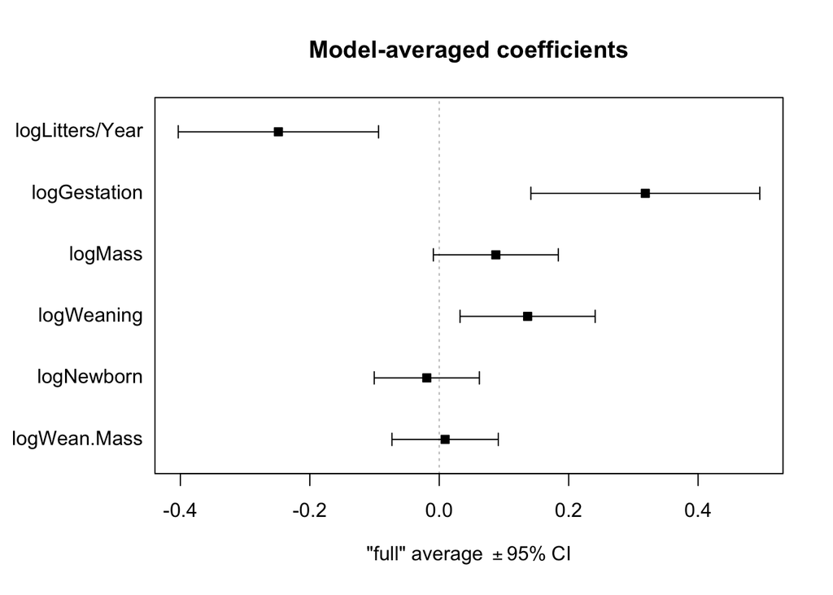

```r
plot(mods.avg1, full = TRUE, intercept = FALSE)
```

```r
#Model-Average Coefficients and CIs for top models for AFR
m_AFR <- lm(data = d, logAFR ~ logGestation + logNewborn + logWeaning + logWean.Mass + `logLitters/Year` + logMass, na.action = "na.fail")
ms_AFR <- dredge(m_AFR)
```

```
## Fixed term is "(Intercept)"
```

```r
(mods.avg2 <- summary(model.avg(ms_AFR, subset = delta < 4,fit = TRUE)))
```

```
##
## Call:
## model.avg(object = get.models(object = ms_AFR, subset = delta <
##     4))
##
## Component model call:
## lm(formula = logAFR ~ <10 unique rhs>, data = d, na.action = na.fail)
##
## Component models:
##       df  logLik   AICc delta weight
## 1236   6 -154.40 321.23  0.00   0.20
## 1256   6 -154.55 321.52  0.30   0.18
## 126    5 -155.76 321.82  0.59   0.15
## 1246   6 -154.70 321.82  0.59   0.15
## 12356  7 -154.40 323.37  2.14   0.07
## 12346  7 -154.40 323.37  2.14   0.07
## 12456  7 -154.54 323.65  2.43   0.06
## 12     4 -157.96 324.12  2.89   0.05
## 123    5 -157.26 324.81  3.58   0.03
## 125    5 -157.32 324.94  3.71   0.03
##
## Term codes:
## `logLitters/Year`      logGestation           logMass        logNewborn
##                 1                 2                 3                 4
##      logWean.Mass        logWeaning
##                 5                 6
##
## Model-averaged coefficients:
## (full average)
##                    Estimate Std. Error Adjusted SE z value Pr(>|z|)
## (Intercept)        2.059308   0.164411    0.165109  12.472  < 2e-16 ***
## `logLitters/Year` -0.736632   0.096521    0.097003   7.594  < 2e-16 ***
## logGestation       0.424816   0.104323    0.104789   4.054 5.04e-05 ***
## logMass            0.013294   0.029383    0.029501   0.451    0.652
## logWeaning         0.125434   0.073485    0.073759   1.701    0.089 .
## logWean.Mass       0.009906   0.031169    0.031308   0.316    0.752
## logNewborn         0.006295   0.028974    0.029108   0.216    0.829
##
## (conditional average)
##                   Estimate Std. Error Adjusted SE z value Pr(>|z|)
## (Intercept)        2.05931    0.16441     0.16511  12.472  < 2e-16 ***
## `logLitters/Year` -0.73663    0.09652     0.09700   7.594  < 2e-16 ***
## logGestation       0.42482    0.10432     0.10479   4.054 5.04e-05 ***
## logMass            0.03511    0.03891     0.03915   0.897   0.3698
## logWeaning         0.14159    0.06171     0.06207   2.281   0.0225 *
## logWean.Mass       0.02921    0.04797     0.04823   0.606   0.5448
## logNewborn         0.02227    0.05113     0.05140   0.433   0.6648
## ---
## Signif. codes:  0 '***' 0.001 '**' 0.01 '*' 0.05 '.' 0.1 ' ' 1
```

```r
confint
```

```
## function (object, parm, level = 0.95, ...)
## UseMethod("confint")
## <bytecode: 0x105946c08>
## <environment: namespace:stats>
```

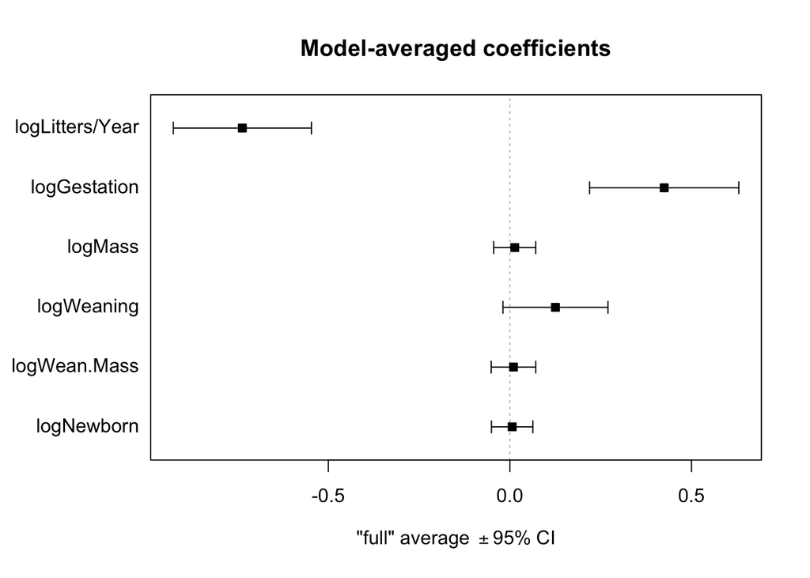

```r
plot(mods.avg2, full = TRUE, intercept = FALSE)
```